# Spillovers to LMICs (excl. China) — LMIC-origin vs HIC-origin innovations

Innovation Strategy Explorer — insights

2026-04-22

## What this note shows

How much per-innovation spillover value do different technologies generate **for LMICs excluding China** — and does this depend on where the innovation was filed? The grouped bar chart below compares two populations of innovations, both scored on the *same* destination flow (*Average Spillovers to LMICs (excl. China)* = `ev_emdenocn`) and both restricted to **granted** patent families (the app’s default):

- **LMIC-origin** innovations, excluding China
- **HIC-origin** innovations

Technologies are on the x-axis; within each technology the two bars show the average spillover value per innovation that flows to LMICs (excl. China), for the two origin groups. An overlaid **circle marker** reports the **LMIC share of total innovation in that category** (LMIC-origin family count ÷ all-origin family count), read off a secondary axis.

## Data source

Three downloads from the public Country Explorer tab of https://mondpanther-iseapp2.share.connect.posit.cloud/, with **Value flow = *Average Spillovers to LMICs (excl. China)*** and **Granted families only** in all three cases, and only the **Country / Group** filter changing. Click any “open in app” link below to jump directly to the bookmarked view used for that row:

| File in `insights/data/` | `country-country` filter | Granted only? | App view |
| --- | --- | --- | --- |
| `flow_LMIC_to_LMIC_granted.csv` | `LMICs (excl. China)` | yes | open in app |
| `flow_HIC_to_LMIC_granted.csv` | `High income countries` | yes | open in app |
| `flow_All_to_LMIC_granted.csv` | `All countries` (for share denominator) | yes | open in app |

## Figure — average spillover value to LMICs (excl. China) per innovation, by technology and origin

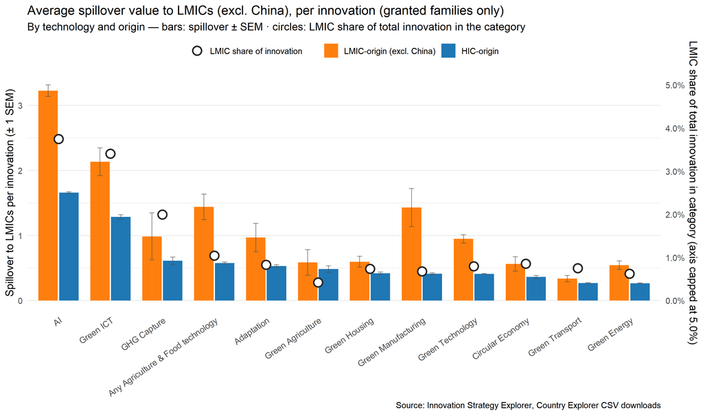

## Reading the chart

- Within each technology group, the **blue** bar is the average LMIC-bound spillover per HIC-origin innovation; the **orange** bar is the same figure for LMIC-origin innovations (excl. China). Read against the **left axis** (spillover per innovation).
- The **open circle** above each group is the LMIC share of total innovation in that technology category — read against the **right axis**.
- Error bars are $\pm$ one standard error of the mean.
- Technologies are sorted left-to-right by HIC-origin magnitude.

If orange sits *above* blue for a technology, LMIC-filed innovations in that field inject more downstream value into other LMICs per innovation than HIC-filed innovations do. A blue-above-orange pattern, conversely, suggests HIC-origin innovations are more strongly absorbed into LMIC citation networks (either because they set the technological frontier or because LMIC examiners cite them disproportionately).

## Summary table

Per-innovation LMIC-spillover means by technology and origin (granted families only).

| Technology | Mean LMIC→LMIC | Mean HIC→LMIC | SEM LMIC→LMIC | SEM HIC→LMIC | N LMIC-origin | N HIC-origin | Ratio LMIC / HIC |
| --- | --- | --- | --- | --- | --- | --- | --- |
| AI | 3.22 | 1.66 | 0.09 | 0.01 | 10604 | 197453 | 1.94 |
| Green ICT | 2.13 | 1.29 | 0.21 | 0.03 | 928 | 15500 | 1.66 |
| GHG Capture | 0.99 | 0.61 | 0.36 | 0.06 | 78 | 2559 | 1.61 |
| Any Agriculture & Food technology | 1.44 | 0.58 | 0.20 | 0.01 | 1545 | 57555 | 2.49 |
| Adaptation | 0.97 | 0.53 | 0.22 | 0.02 | 971 | 26082 | 1.82 |
| Green Agriculture | 0.59 | 0.48 | 0.19 | 0.05 | 110 | 4477 | 1.21 |
| Green Housing | 0.60 | 0.42 | 0.08 | 0.02 | 688 | 27778 | 1.42 |
| Green Manufacturing | 1.43 | 0.41 | 0.29 | 0.01 | 898 | 39307 | 3.46 |
| Green Technology | 0.95 | 0.41 | 0.06 | 0.01 | 6511 | 265940 | 2.31 |
| Circular Economy | 0.56 | 0.36 | 0.11 | 0.02 | 519 | 14452 | 1.55 |
| Green Transport | 0.34 | 0.27 | 0.05 | 0.01 | 813 | 61034 | 1.25 |
| Green Energy | 0.54 | 0.27 | 0.06 | 0.01 | 2118 | 113544 | 2.05 |

## Notes & caveats

- Both bars use the same destination flow `ev_emdenocn` — *Average Spillovers to LMICs (excl. China)* — so the levels are directly comparable within a technology.
- The sample size column `innos` is **not** the same across origins: LMIC innovator pools are smaller, so their SEMs are typically larger. Treat any orange/blue gap inside a large SEM with caution.
- Only **granted** patent families are included (the app’s default).
- The origin-country filter selects patents filed from the relevant country group; downstream-citing patents can come from anywhere in the world, but only LMIC (excl. China) citations count toward `ev_emdenocn`.
- Data acquisition uses only the app’s public CSV-download endpoint (via `chromote`) — the patent database is never accessed directly.

Rendered 2026-04-22 13:01 BST · app version `unknown`